# Reproducible Research Course Project 2

# 4. RESULTS

QUESTION 1. Across the United States, which types of events (as indicated in the EVTYPE variable) are most harmful with respect to population health?

Selection of variables of interest

```r
SelectVar<-c("EVTYPE","FATALITIES","INJURIES","PROPDMG", "PROPDMGEXP","CROPDMG","CROPDMGEXP")
variableStorm<-storm[SelectVar]
```

Dangerous Events with respect to Population Health

To find the event types that are most harmful to population health, the number of casualties are aggregated by the event type.

```r
casualties <- ddply(storm, .(EVTYPE), summarize,
                    fatalities = sum(FATALITIES),
                    injuries = sum(INJURIES))
```

Events that cause most deaths and injuries

```r
topTenFatalities <- head(casualties[order(casualties$fatalities, decreasing = T), ], 10)
topTenInjuries <- head(casualties[order(casualties$injuries, decreasing = T), ], 10)
```

Top ten events that caused the most deaths

Group the top ten fatalities by event type and sort in descending order

```r
topTenFatalities[, c("EVTYPE", "fatalities")]
```

|  | EVTYPE | fatalities |
| --- | --- | --- |
| 741 | tornado | 5633 |
| 116 | excessive heat | 1903 |
| 138 | flash flood | 978 |
| 240 | heat | 937 |
| 410 | lightning | 816 |
| 762 | tstm wind | 504 |
| 154 | flood | 470 |
| 515 | rip current | 368 |
| 314 | high wind | 248 |
| 19 | avalanche | 224 |

Top ten events that caused most number of injuries

Group the top ten injuries by event type and sort in descending order

```r
topTenInjuries[, c("EVTYPE", "injuries")]
```

|  | EVTYPE | injuries |
| --- | --- | --- |
| 741 | tornado | 91346 |
| 762 | tstm wind | 6957 |
| 154 | flood | 6789 |
| 116 | excessive heat | 6525 |
| 410 | lightning | 5230 |
| 240 | heat | 2100 |
| 382 | ice storm | 1975 |
| 138 | flash flood | 1777 |
| 671 | thunderstorm wind | 1488 |
| 209 | hail | 1361 |

Graph of the main deaths and injuries by types of meteorological events

Plot graphs showing the top ten fatalities and injuries

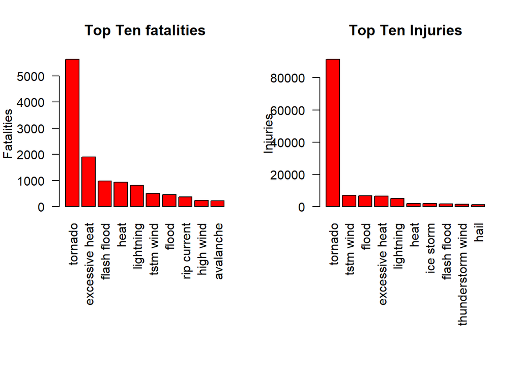

```r
par(mfrow=c(1,2),mar=c(11,4,4,2))
barplot(topTenFatalities$fatalities,names.arg=topTenFatalities$EVTYPE,las=2,col="red",ylab="Fatalities",main="Top Ten fatalities")
barplot(topTenInjuries$injuries,names.arg=topTenInjuries$EVTYPE,las=2,col="red",ylab="Injuries",main="Top Ten Injuries")
```

Analysis: The meteorological event with the greatest impact on the population turned out to be the Tornado (with the highest number of deaths and injuries)

QUESTION 2. Across the United States, which types of events have the greatest economic consequences?

Meteorological events with the greatest economic impact

Data Exploration

When reviewing the data we find columns for property damage (PROPDMG) and crop damage (CROPDMG), in addition there are other related columns of exponents (PROPDMGEXP and CROPDMGEXP). We will transform the columns of exponents into numerical data to facilitate the respective calculations of damage to property and crops

Property damage analysis

Property damage exponents by level will be listed and assigned with their exponent data values. Invalid data is excluded by assigning the value ‘0’. So, the property damage value is calculated by multiplying the property damage and the property exponent value.

```r
unique(variableStorm$PROPDMGEXP)
```

```
##  [1] "K" "M" ""  "B" "m" "+" "0" "5" "6" "?" "4" "2" "3" "h" "7" "H" "-" "1" "8"
```

Calculation of values of the exponent property in variableStorm

```r
variableStorm$PROPEXP[variableStorm$PROPDMGEXP == "K"] <- 1000
variableStorm$PROPEXP[variableStorm$PROPDMGEXP == "M"] <- 1e+06
variableStorm$PROPEXP[variableStorm$PROPDMGEXP == ""] <- 1
variableStorm$PROPEXP[variableStorm$PROPDMGEXP == "B"] <- 1e+09
variableStorm$PROPEXP[variableStorm$PROPDMGEXP == "m"] <- 1e+06
variableStorm$PROPEXP[variableStorm$PROPDMGEXP == "0"] <- 1
variableStorm$PROPEXP[variableStorm$PROPDMGEXP == "5"] <- 1e+05
variableStorm$PROPEXP[variableStorm$PROPDMGEXP == "6"] <- 1e+06
variableStorm$PROPEXP[variableStorm$PROPDMGEXP == "4"] <- 10000
variableStorm$PROPEXP[variableStorm$PROPDMGEXP == "2"] <- 100
variableStorm$PROPEXP[variableStorm$PROPDMGEXP == "3"] <- 1000
variableStorm$PROPEXP[variableStorm$PROPDMGEXP == "h"] <- 100
variableStorm$PROPEXP[variableStorm$PROPDMGEXP == "7"] <- 1e+07
variableStorm$PROPEXP[variableStorm$PROPDMGEXP == "H"] <- 100
variableStorm$PROPEXP[variableStorm$PROPDMGEXP == "1"] <- 10
variableStorm$PROPEXP[variableStorm$PROPDMGEXP == "8"] <- 1e+08
```

Set ‘0’ to invalid exponent variableStorm

```r
variableStorm$PROPEXP[variableStorm$PROPDMGEXP == "+"] <- 0
variableStorm$PROPEXP[variableStorm$PROPDMGEXP == "-"] <- 0
variableStorm$PROPEXP[variableStorm$PROPDMGEXP == "?"] <- 0
```

Calculate the value of material damage

```r
variableStorm$PROPDMGVAL <- variableStorm$PROPDMG * variableStorm$PROPEXP
```

Property Crop Damage

Crop damage exponents for each level listed out & assigned those values for the crop exponent data. Invalid data was excluded by assigning the value as ‘0’. Then, the crop damage value was calculated by multiplying the crop damage and crop exponent value.

```r
unique(variableStorm$CROPDMGEXP)
```

```
## [1] ""  "M" "K" "m" "B" "?" "0" "k" "2"
```

Calculation values for the crop exponent variableStorm

```r
variableStorm$CROPEXP[variableStorm$CROPDMGEXP == "M"] <- 1e+06
variableStorm$CROPEXP[variableStorm$CROPDMGEXP == "K"] <- 1000
variableStorm$CROPEXP[variableStorm$CROPDMGEXP == "m"] <- 1e+06
variableStorm$CROPEXP[variableStorm$CROPDMGEXP == "B"] <- 1e+09
variableStorm$CROPEXP[variableStorm$CROPDMGEXP == "0"] <- 1
variableStorm$CROPEXP[variableStorm$CROPDMGEXP == "k"] <- 1000
variableStorm$CROPEXP[variableStorm$CROPDMGEXP == "2"] <- 100
variableStorm$CROPEXP[variableStorm$CROPDMGEXP == ""] <- 1
```

Set ‘0’ to invalid exponent variableStorm

```r
variableStorm$CROPEXP[variableStorm$CROPDMGEXP == "?"] <- 0
```

Calculating the crop damage

```r
variableStorm$CROPDMGVAL <- variableStorm$CROPDMG * variableStorm$CROPEXP
```

Property Damage Summary

Set property damage by event type and sort in descending order

```r
propDamage <- aggregate(PROPDMGVAL~EVTYPE,data=variableStorm,FUN=sum,na.rm=TRUE)
propDamage <-propDamage[with(propDamage,order(-PROPDMGVAL)),]
propDamage <- head(propDamage,10)
print(propDamage)
```

```
##                EVTYPE   PROPDMGVAL
## 154             flood 144657709807
## 366 hurricane typhoon  69305840000
## 741           tornado  56947380617
## 585       storm surge  43323536000
## 138       flash flood  16822673979
## 209              hail  15735267513
## 357         hurricane  11868319010
## 755    tropical storm   7703890550
## 866      winter storm   6688497251
## 314         high wind   5270046260
```

Crop Damage Summary

Crop damage by event type, sort descending

```r
cropDamage <- aggregate(CROPDMGVAL~EVTYPE,data=variableStorm,FUN=sum,na.rm=TRUE)
cropDamage <- cropDamage[with(cropDamage,order(-CROPDMGVAL)),]
cropDamage <- head(cropDamage,10)
print(cropDamage)
```

```
##                EVTYPE  CROPDMGVAL
## 84            drought 13972566000
## 154             flood  5661968450
## 519       river flood  5029459000
## 382         ice storm  5022113500
## 209              hail  3025954473
## 357         hurricane  2741910000
## 366 hurricane typhoon  2607872800
## 138       flash flood  1421317100
## 125      extreme cold  1312973000
## 185      frost freeze  1094186000
```

Graph of the economic consequences according to the type of climatic event

Graph top ten property and crop damage

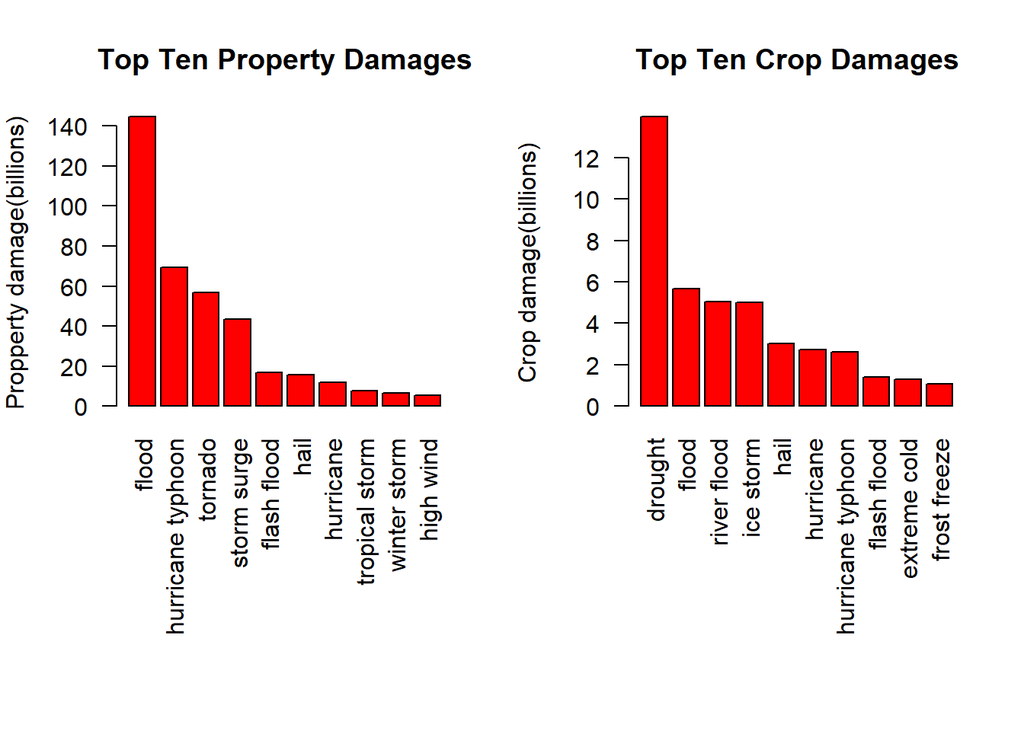

```r
par(mfrow=c(1,2), mar = c(11,4,4,2))
barplot(propDamage$PROPDMGVAL/(10^9),names.arg=propDamage$EVTYPE,las=2,col="red",ylab="Propperty damage(billions)",main="Top Ten Property Damages")
barplot(cropDamage$CROPDMGVAL/(10^9),names.arg=cropDamage$EVTYPE,las=2,col="red",ylab="Crop damage(billions)",main="Top Ten Crop Damages")
```

# 5. Conclusions

1. Tornadoes are responsible for the greatest number of deaths and injuries, followed by excessive heat and storm wind for injuries.
2. Floods are responsible for the most damage to property, while droughts cause the most damage to crops.